# awtools

# a_theme

A simple, distilled, #rstats theme used mainly on [www.austinwehrwein.com](https://austinwehrwein.com/)

My main theme now is the `a_plex_theme` which the fonts are available from Google Fonts:

- [IBM Plex Mono](https://fonts.google.com/specimen/IBM+Plex+Mono) (plot title, legend)
- [Open Sans](https://fonts.google.com/specimen/Open+Sans) (subtitle, captions, axis_text)

The original `a_theme` uses fonts that can be found and downloaded from Google Fonts:

- [Roboto](https://fonts.google.com/specimen/Slabo+27px) (plot title, legend)
- [Open Sans](https://fonts.google.com/specimen/Open+Sans) (subtitle, captions, axis_text)

The new `a_robot_theme` uses fonts that can be found and downloaded from Google Fonts:

- [Roboto Slab](https://fonts.google.com/specimen/Roboto+Slab) (plot title, legend)
- [Roboto Light](https://fonts.google.com/specimen/Roboto) (subtitle, captions, axis_text)

The new `a_concert_theme` uses fonts that can be found and downloaded from Google Fonts:

- [Concert One](https://fonts.google.com/specimen/Concert+One) (plot title, axis_title)
- Inconsolata (subtitle, captions, axis_text)

## New Examples

#### `a_plex_theme` features:

- grid: [TRUE/FALSE] turns off the main panel grids.
- noaxis: [TRUE/FALSE] turns off the axis of the plot, seen mainly in maps.
- emphasis: [‘x’,‘y’,‘xy’] adds a bold to an axis title for emphasis.

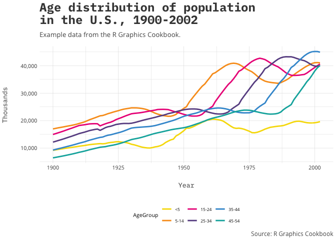

```r
groups<-unique(uspopage$AgeGroup)
uspopage<-uspopage%>%
  filter(uspopage$AgeGroup %in% head(groups,6))
ggplot(uspopage, aes(x=Year, y=Thousands, color=AgeGroup)) +
  geom_line(size=1) +
  a_primary_color() +
  scale_y_continuous(labels = scales::comma)+
  labs(title="Age distribution of population\nin the U.S., 1900-2002",
       subtitle="Example data from the R Graphics Cookbook.",
       caption="Source: R Graphics Cookbook") +
  a_plex_theme() +
  theme(legend.position="bottom")
```

A new update to the awtools package sees a new dark theme that is based on the main plex theme.

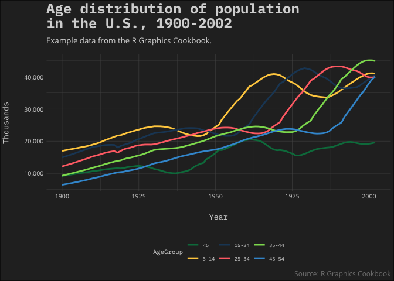

```r
ggplot(uspopage, aes(x=Year, y=Thousands, color=AgeGroup)) +
  geom_line(size=1) +
  a_main_color() +
  scale_y_continuous(labels = scales::comma)+
  labs(title="Age distribution of population\nin the U.S., 1900-2002",
       subtitle="Example data from the R Graphics Cookbook.",
       caption="Source: R Graphics Cookbook") +
  a_dark_theme() +
  theme(legend.position="bottom")
```

And a new `a_gray_color` and `a_gray_palette` which is a simple four color grays palette.

```r
lax<-read_csv('https://raw.githubusercontent.com/awhstin/temperaturesv2/master/LAX-NCDC-2015-18.csv') %>%
  filter(months(DATE)=='January')%>%
  mutate(year=format(DATE,'%Y'),
         month=factor(months(DATE), levels=rev(month.name)))
```

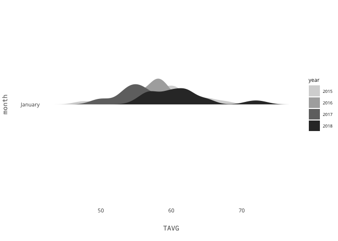

```r
ggplot(lax, aes(x=TAVG, y=month, fill=year)) +
  geom_density_ridges(scale=.9, color=NA) +
  a_plex_theme(grid=FALSE) +
  a_gray_fill()
```

## Old examples

Here is a simple scatterplot with the original `a_theme`.

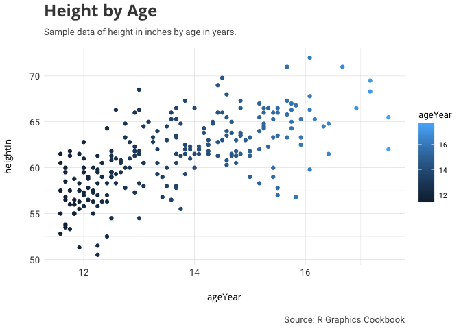

```r
ggplot(heightweight,aes(x=ageYear,y=heightIn,color=ageYear))+
  geom_point()+
  a_theme()+
  labs(title='Height by Age',
       subtitle='Sample data of height in inches by age in years.',
       caption='Source: R Graphics Cookbook')
```

Here is an example of the color palette.

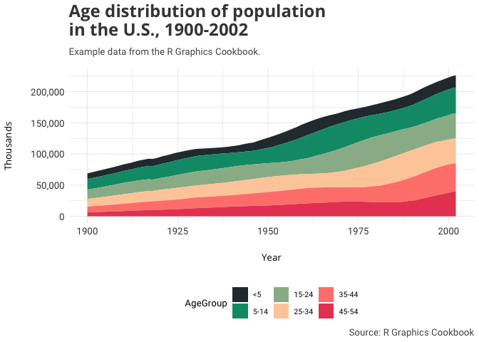

```r
ggplot(uspopage, aes(x=Year, y=Thousands, fill=AgeGroup)) +
  geom_area() +
  a_scale_fill() +
  scale_y_continuous(labels = scales::comma)+
  labs(title="Age distribution of population\nin the U.S., 1900-2002",
       subtitle="Example data from the R Graphics Cookbook.",
       caption="Source: R Graphics Cookbook") +
  a_theme() +
  theme(legend.position="bottom")
```

I also created a reverse of the color palette which is debuted along with the ‘a_robot_theme’.

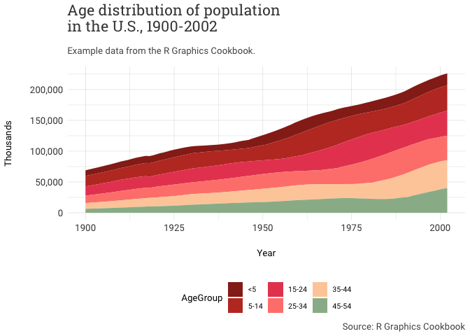

```r
ggplot(uspopage, aes(x=Year, y=Thousands, fill=AgeGroup)) +
  geom_area() +
  a_reversed_fill() +
  scale_y_continuous(labels = scales::comma)+
  labs(title="Age distribution of population\nin the U.S., 1900-2002",
       subtitle="Example data from the R Graphics Cookbook.",
       caption="Source: R Graphics Cookbook") +
  a_robot_theme() +
  theme(legend.position="bottom")
```

Finally for work I compare 4 and 6 factors often so I created a stepped version of my color palette.

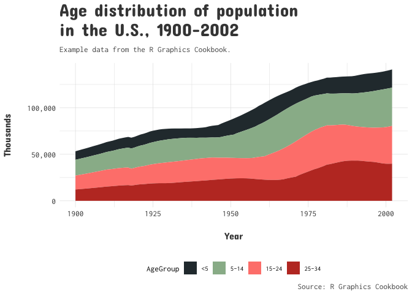

```r
groups<-unique(uspopage$AgeGroup)
uspopages<-uspopage%>%
  filter(uspopage$AgeGroup %in% head(groups,4))
ggplot(uspopages, aes(x=Year, y=Thousands, fill=AgeGroup)) +
  geom_area() +
  a_step_fill() +
  scale_y_continuous(labels = scales::comma)+
  labs(title="Age distribution of population\nin the U.S., 1900-2002",
       subtitle="Example data from the R Graphics Cookbook.",
       caption="Source: R Graphics Cookbook") +
  a_concert_theme() +
  theme(legend.position="bottom")
```

Finally a little display of a new color palette.

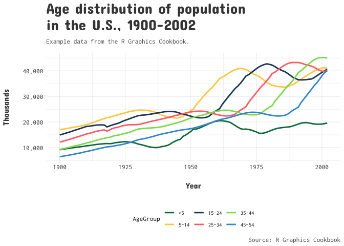

```r
groups<-unique(uspopage$AgeGroup)
uspopage<-uspopage%>%
  filter(uspopage$AgeGroup %in% head(groups,6))
ggplot(uspopage, aes(x=Year, y=Thousands, color=AgeGroup)) +
  geom_line(size=1) +
  a_main_color() +
  scale_y_continuous(labels = scales::comma)+
  labs(title="Age distribution of population\nin the U.S., 1900-2002",
       subtitle="Example data from the R Graphics Cookbook.",
       caption="Source: R Graphics Cookbook") +
  a_concert_theme() +
  theme(legend.position="bottom")
```